# StormData Analysis for US with Population Harm and Property Damage

Ramesh Chellaton

11/13/2019

## Synopsis

The analysis looks at fatality and property damage data collected for US from 1950 to 2011. The information includes state, county, event dates, damage and fatality data, some event data, etc. From analysis of the data, tornadoes were responsible for most fatalities.

### load libraries

```r
library(dplyr)
```

```r
library(ggplot2)
```

### About the data file

The file came from: https://d396qusza40orc.cloudfront.net/repdata%2Fdata%2FStormData.csv.bz2 The file was unzipped using ‘archive’ utility on MacOs. One can also use `bzip2 -d repdata-data-StormData.csv.bz2` to do the same. The unzipped file is a CSV with 902,297 rows and 37 columns. So, load using read.csv function.

```r
stormData <- read.csv("repdata-data-StormData.csv", stringsAsFactors = FALSE)
#summary(stormData)
```

### Data Processing

We are interested in population harm data - in column FATALITIES & INJURIES, and economic loss data - PROPDMG & CROPDMG along with the exponential factor columns. And need to summarize for US wide aggregation to find the event that has the highest fatality rate. Also, property damage data is split in 2 columns - PROPDMG and PROPDMGEXP. PROPDMGEXP has value K,M,B or for a thousand, million, or billion multiplier. Similarily for CROPDMG & CROPDMGEXP.

```r
shortData <- stormData %>% select(6:8,23:28)
shortData <- stormData %>%
  mutate(propDamage = case_when (
                        PROPDMGEXP=='K' ~ PROPDMG*10^3,
                        PROPDMGEXP=='M' ~ PROPDMG*10^6,
                        PROPDMGEXP=='B' ~ PROPDMG*10^9,
                        TRUE ~ PROPDMG),
         cropDamage = case_when(
                        CROPDMGEXP=='K' ~ CROPDMG*10^3,
                        CROPDMGEXP=='M' ~ CROPDMG*10^6,
                        CROPDMGEXP=='B' ~ CROPDMG*10^9,
                        TRUE ~ CROPDMG),
         totalDamage = propDamage + cropDamage,
         popHarm = FATALITIES + INJURIES)
```

```r
summEVTYPE <- shortData %>% group_by(EVTYPE)

aggStormData_popHarm <- aggregate(popHarm ~ EVTYPE, summEVTYPE, FUN=sum)
aggStormData_popHarm <- subset(aggStormData_popHarm, popHarm > 0)
aggStormData_popHarm <- aggStormData_popHarm[order(aggStormData_popHarm$popHarm,
                                                     decreasing=TRUE),]
aggStormData_popHarm <- subset(aggStormData_popHarm,
                                popHarm > quantile(aggStormData_popHarm$popHarm,.95))
```

```r
aggStormData_Economic <- aggregate(totalDamage ~ EVTYPE, summEVTYPE, FUN=sum)
aggStormData_Economic <- subset(aggStormData_Economic, totalDamage > 0)
aggStormData_Economic <- aggStormData_Economic[order(aggStormData_Economic$totalDamage,
                                                     decreasing=TRUE),]

aggStormData_Economic <- subset(aggStormData_Economic,
                                totalDamage > quantile(aggStormData_Economic$totalDamage, .98))
```

### Results

Here, we generate a plot to look at fatality rate for 95 percentile group of events with non-zero fatality count.

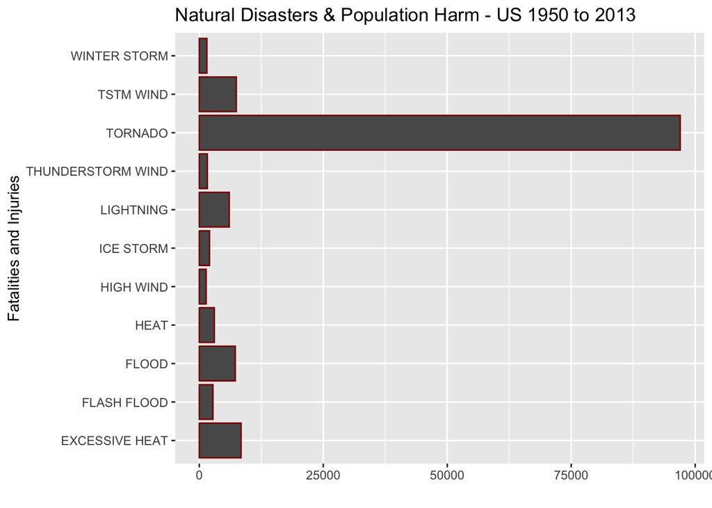

```r
g1 <- ggplot(aggStormData_popHarm, mapping=aes(x=EVTYPE, y=popHarm)) +
  geom_bar(stat="identity", color='dark red') +
  ggtitle("Natural Disasters & Population Harm - US 1950 to 2013") +
  xlab("Fatalities and Injuries") + ylab("") + coord_flip()

print(g1)
```

… And a plot to look at economic loss pattern for 98th percentile.

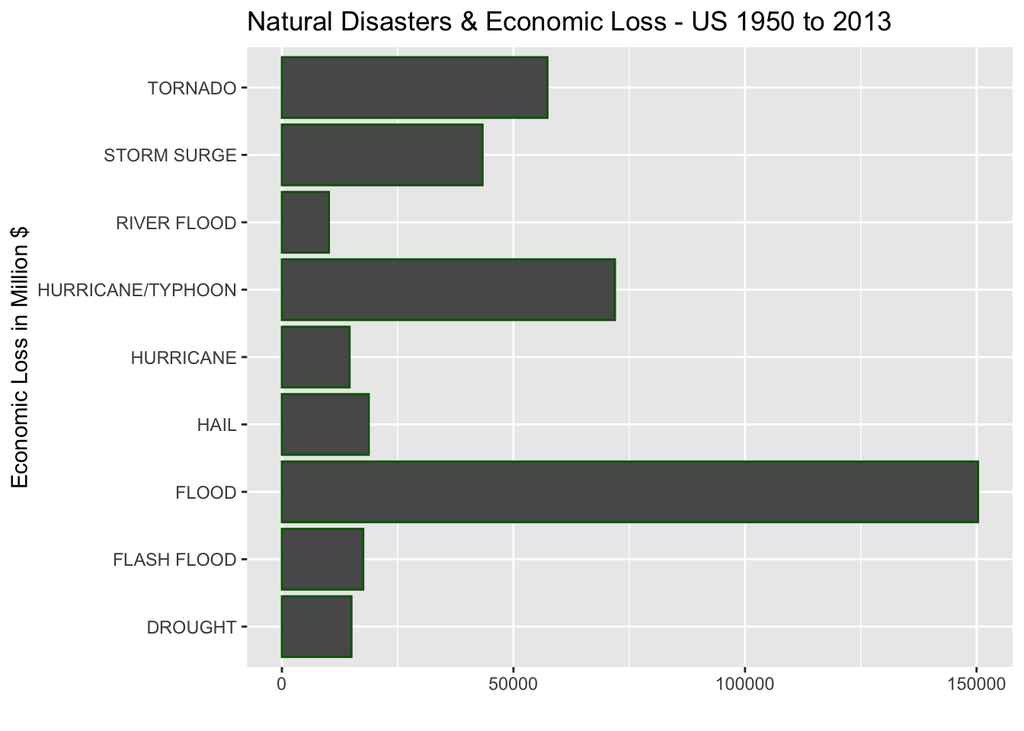

```r
g2 <- ggplot(aggStormData_Economic, mapping=aes(x=EVTYPE, y=totalDamage/10^6)) +
  geom_bar(stat="identity", color='dark green') +
  ggtitle("Natural Disasters & Economic Loss - US 1950 to 2013") +
  ylab("") + xlab("Economic Loss in Million $") + coord_flip()
print(g2)
```

### Results

```r
print(paste("Event with highest economic loss: ", aggStormData_Economic$EVTYPE[1]))
```

```
## [1] "Event with highest economic loss:  FLOOD"
```

```r
print(paste("Event with highest fatalities & injuries: ", aggStormData_popHarm$EVTYPE[1]))
```

```
## [1] "Event with highest fatalities & injuries:  TORNADO"
```